# SHIPMENT-PRICING

```python
import pandas as pd
import numpy as np
import seaborn as sns
import matplotlib.pyplot as plt
```

#### Original Data Source : https://data.usaid.gov/HIV-AIDS/Supply-Chain-Shipment-Pricing-Data/a3rc-nmf6

#### This data set provides supply chain health commodity shipment and pricing data. Specifically, the data set identifies Antiretroviral (ARV) and HIV lab shipments to supported countries. In addition, the data set provides the commodity pricing and associated supply chain expenses necessary to move the commodities to countries for use. The dataset has similar fields to the Global Fund's Price, Quality and Reporting (PQR) data. PEPFAR and the Global Fund represent the two largest procurers of HIV health commodities. This dataset, when analyzed in conjunction with the PQR data, provides a more complete picture of global spending on specific health commodities. The data are particularly valuable for understanding ranges and trends in pricing as well as volumes delivered by country. The US Government believes this data will help stakeholders make better, data-driven decisions. Care should be taken to consider contextual factors when using the database. Conclusions related to costs associated with moving specific line items or products to specific countries and lead times by product/country will not be accurate.

```python
# Reading the Data

pd.set_option('display.max_columns', 40)
data=pd.read_csv(r"C:\Users\Shashank Sundi\Desktop\I neuron\assignments\SCM SHIPMENT PRICING\SCMS_Delivery_History_Dataset.csv")
data.head()
```

|  | ID | Project Code | PQ # | PO / SO # | ASN/DN # | Country | Managed By | Fulfill Via | Vendor INCO Term | Shipment Mode | PQ First Sent to Client Date | PO Sent to Vendor Date | Scheduled Delivery Date | Delivered to Client Date | Delivery Recorded Date | Product Group | Sub Classification | Vendor | Item Description | Molecule/Test Type | Brand | Dosage | Dosage Form | Unit of Measure (Per Pack) | Line Item Quantity | Line Item Value | Pack Price | Unit Price | Manufacturing Site | … |
| --- | --- | --- | --- | --- | --- | --- | --- | --- | --- | --- | --- | --- | --- | --- | --- | --- | --- | --- | --- | --- | --- | --- | --- | --- | --- | --- | --- | --- | --- | --- |
| 0 | 1 | 100-CI-T01 | Pre-PQ Process | SCMS-4 | ASN-8 | Côte d'Ivoire | PMO - US | Direct Drop | EXW | Air | Pre-PQ Process | Date Not Captured | 2-Jun-06 | 2-Jun-06 | 2-Jun-06 | HRDT | HIV test | RANBAXY Fine Chemicals LTD. | HIV, Reveal G3 Rapid HIV-1 Antibody Test, 30 T... | HIV, Reveal G3 Rapid HIV-1 Antibody Test | Reveal | NaN | Test kit | 30 | 19 | 551.0 | 29.00 | 0.97 | Ranbaxy Fine Chemicals LTD | … |
| 1 | 3 | 108-VN-T01 | Pre-PQ Process | SCMS-13 | ASN-85 | Vietnam | PMO - US | Direct Drop | EXW | Air | Pre-PQ Process | Date Not Captured | 14-Nov-06 | 14-Nov-06 | 14-Nov-06 | ARV | Pediatric | Aurobindo Pharma Limited | Nevirapine 10mg/ml, oral suspension, Bottle, 2... | Nevirapine | Generic | 10mg/ml | Oral suspension | 240 | 1000 | 6200.0 | 6.20 | 0.03 | Aurobindo Unit III, India | … |
| 2 | 4 | 100-CI-T01 | Pre-PQ Process | SCMS-20 | ASN-14 | Côte d'Ivoire | PMO - US | Direct Drop | FCA | Air | Pre-PQ Process | Date Not Captured | 27-Aug-06 | 27-Aug-06 | 27-Aug-06 | HRDT | HIV test | Abbott GmbH & Co. KG | HIV 1/2, Determine Complete HIV Kit, 100 Tests | HIV 1/2, Determine Complete HIV Kit | Determine | NaN | Test kit | 100 | 500 | 40000.0 | 80.00 | 0.80 | ABBVIE GmbH & Co.KG Wiesbaden | … |
| 3 | 15 | 108-VN-T01 | Pre-PQ Process | SCMS-78 | ASN-50 | Vietnam | PMO - US | Direct Drop | EXW | Air | Pre-PQ Process | Date Not Captured | 1-Sep-06 | 1-Sep-06 | 1-Sep-06 | ARV | Adult | SUN PHARMACEUTICAL INDUSTRIES LTD (RANBAXY LAB... | Lamivudine 150mg, tablets, 60 Tabs | Lamivudine | Generic | 150mg | Tablet | 60 | 31920 | 127360.8 | 3.99 | 0.07 | Ranbaxy, Paonta Shahib, India | … |
| 4 | 16 | 108-VN-T01 | Pre-PQ Process | SCMS-81 | ASN-55 | Vietnam | PMO - US | Direct Drop | EXW | Air | Pre-PQ Process | Date Not Captured | 11-Aug-06 | 11-Aug-06 | 11-Aug-06 | ARV | Adult | Aurobindo Pharma Limited | Stavudine 30mg, capsules, 60 Caps | Stavudine | Generic | 30mg | Capsule | 60 | 38000 | 121600.0 | 3.20 | 0.05 | Aurobindo Unit III, India | … |

#### Data Description

##### 1. ID - identity number

##### 2. Project Code - Project code for the shipment

##### 3. PQ # - Price quote (PQ) number

##### 4. PO / SO # - Price Order / Sales Order --- PO is a buyer's request to a seller (supplier) to order the goods/services

##### 5. ASN/DN # - Shipment number: Advanced Shipment Note (ASN) for Direct Drop deliveries, or Delivery Note (DN) for from RDC deliveries

##### 6. Country - Destination country , where shipment is to be delivered

##### 7. Managed By - SCMS managing office: either the Program Management Office (PMO) in the U.S. or the relevant SCMS field office

##### 8. Fulfill Via - Method through which the shipment was fulfilled: via Direct Drop from vendor or from stock available in the RDCs( retail distribution centers )

##### 9. Vendor INCO Term - The vendor INCO term (also known as International Commercial Terms) for Direct Drop deliveries---a set of 11 internationally recognized rules which define the responsibilities of sellers and buyers. Incoterms specifies who is responsible for paying for and managing the shipment, insurance, documentation, customs clearance, and other logistical activities.

##### 10. Shipment Mode - Method by which commodities are shipped

##### 11. PQ First Sent to Client Date - Date the PQ is first sent to the client

##### 12. PO Sent to Vendor Date - Date the PO is first sent to the vendor

##### 13. Scheduled Delivery Date - Date on which delivery to client was recorded in SCMS information systems

##### 14. Product Group - Product group for item, i.e. ARV, HRDT

##### 15. Sub Classification - Identifies relevant product sub classifications, such as whether ARVs are pediatric or adult, whether a malaria product is an artemisinin-based combination therapy (ACT), etc.

##### 16. Vendor - Vendor name

##### 17. Item Description - Product name and formulation from Partnership for Supply Chain Management (PFSCM) Item Master

##### 18. Molecule/Test Type - Active drug(s) or test kit type

##### 19. Brand - Generic or branded name for the item

##### 20. Dosage - Item dosage and unit

##### 21. Dosage Form - Dosage form for the item (tablet, oral solution, injection, etc.).

##### 22. Unit of Measure (Per Pack) - Pack quantity (pills or test kits) used to compute unit price

##### 23. Line Item Quantity - Total quantity (packs) of commodity per line item

##### 24. Line Item Value - Total value of commodity per line item

##### 25. Pack Price - Cost per pack (i.e. month s supply of ARVs, pack of 60 test kits)

##### 26. Unit Price - Cost per pill (for drugs) or per test (for test kits)

##### 27. Manufacturing Site - Identifies manufacturing site for the line item for direct drop and from RDC deliveries

##### 28. First Line Designation - Designates if the line in question shows the aggregated freight costs and weight associated with all items on the ASN DN

##### 29. Weight (Kilograms) - Weight for all lines on an ASN DN

##### 30. Freight Cost (USD) - Freight charges associated with all lines on the respective ASN DN

##### 31. Line Item Insurance (USD) - Line item cost of insurance, created by applying an annual flat rate ( ) to commodity cost

```python
# pack price = unit measure per pack * unit price
# Line item value =  no. of items in line * price of a pack

# Target column -----> Shipment Price( total value of transporting the shipment to destination)=freight cost + line item value + Line item insurance
# So we'll create a new feature for that later on
```

```python
# Checking and Validating Data Types

pd.DataFrame(data=data.dtypes.values,index=data.dtypes.index).T

# we can see that columns - Scheduled Delivery Date , 	Delivered to Client Date,	Delivery Recorded Date ,PQ First Sent to Client Date,PO Sent to Vendor Date are dates , but are identified as 'object' type
# We can also see that columns - Weight (Kilograms)	, Freight Cost (USD) are actually numeric values , but are classified as 'object' type
# We need to change the data types of above identified columns
```

|  | ID | Project Code | PQ # | PO / SO # | ASN/DN # | Country | Managed By | Fulfill Via | Vendor INCO Term | Shipment Mode | PQ First Sent to Client Date | PO Sent to Vendor Date | Scheduled Delivery Date | Delivered to Client Date | Delivery Recorded Date | Product Group | Sub Classification | Vendor | Item Description | Molecule/Test Type | Brand | Dosage | Dosage Form | Unit of Measure (Per Pack) | Line Item Quantity | Line Item Value | Pack Price | Unit Price | Manufacturing Site | … |
| --- | --- | --- | --- | --- | --- | --- | --- | --- | --- | --- | --- | --- | --- | --- | --- | --- | --- | --- | --- | --- | --- | --- | --- | --- | --- | --- | --- | --- | --- | --- |
| 0 | int64 | object | object | object | object | object | object | object | object | object | object | object | object | object | object | object | object | object | object | object | object | object | object | int64 | int64 | float64 | float64 | float64 | object | … |

```python
for i in ['Weight (Kilograms)', 'Freight Cost (USD)','PQ First Sent to Client Date','PO Sent to Vendor Date']:
    print(data[i].value_counts().head(),"\n\n")
```

```
Weight Captured Separately    1507
2                               29
6                               26
1                               23
5                               20
Name: Weight (Kilograms), dtype: int64


Freight Included in Commodity Cost    1442
Invoiced Separately                    239
9736.1                                  36
6147.18                                 27
See DN-304 (ID#:10589)                  16
Name: Freight Cost (USD), dtype: int64


Pre-PQ Process       2476
Date Not Captured     205
9/11/14               205
7/11/13               173
4/30/14               123
Name: PQ First Sent to Client Date, dtype: int64


N/A - From RDC       5404
Date Not Captured     328
8/27/14                80
3/19/10                78
8/29/14                76
Name: PO Sent to Vendor Date, dtype: int64
```

```python
# in above cell we observe that some of the weights were weighed separately and hence we don't have info about those weights , so we replace them with nan
# moreover , in freight cost column , the cost was either not read from the ASN/DN , or Invoiced Separately etc.  ; hence it says to read from the tag itself manually ,
#  which is not feasible for every product , so we replace it with nan

# To capture the importance of the fact that it was measured separately ,Weight Captured Separately , freight included in commo..etc. , we'll create a new feature , else we might lose
# some important info

# Creating new feature features to capture importance of special cases where measurements could either not be read , or were recorded separately

# For Freight Cost
data['Freight_cost_special']=0
for i in range(data.shape[0]):

    if data['Freight Cost (USD)'].loc[i]  in ["Freight Included in Commodity Cost",'Invoiced Separately']:
        data['Freight_cost_special'].loc[i]=data['Freight Cost (USD)'].loc[i]

    elif data['Freight Cost (USD)'].loc[i].split(" ")[0]=="See":
        data['Freight_cost_special'].loc[i]="See ASN/DN Tag"

    else :
        data['Freight_cost_special'].loc[i]="Normal Measurement"


# For Shipment weight
data['Weight_special']=0
for i in range(data.shape[0]):

    if data['Weight (Kilograms)'].loc[i]  in ["Weight Captured Separately"]:
        data['Weight_special'].loc[i]=data['Weight (Kilograms)'].loc[i]

    elif data['Weight (Kilograms)'].loc[i].split(" ")[0]=="See":
        data['Weight_special'].loc[i]="See ASN/DN Tag"

    else :
        data['Weight_special'].loc[i]="Normal Measurement"

# For PQ First Sent to Client Date

data['PQ_date_sent']=0
for i in range(data.shape[0]):

    if data['PQ First Sent to Client Date'].loc[i]  in ['Pre-PQ Process','Date Not Captured']:
        data['PQ_date_sent'].loc[i]=data['PQ First Sent to Client Date'].loc[i]
    else :
        data['PQ_date_sent'].loc[i]="Date Captured"

# For PO Sent to Vendor Date

data['PO_date_sent']=0
for i in range(data.shape[0]):

    if data['PO Sent to Vendor Date'].loc[i]  in ['N/A - From RDC' ,'Date Not Captured']:
        data['PO_date_sent'].loc[i]=data['PO Sent to Vendor Date'].loc[i]

    else :
        data['PO_date_sent'].loc[i]="Date Captured"
```

```python
# Converting data types to Datetime

# For PQ First Sent to Client Date	& For PO Sent to Vendor Date --- approximately 30-50% data is missing and the dates are not sequential , so we can't
# impute it in any way . So , after we have captured the importance of missing dates in previous cell . We will drop the two columns----if we had the all dates , then we could have found another feature

for i in ['Scheduled Delivery Date', 'Delivered to Client Date','Delivery Recorded Date']:
    data[i]=pd.to_datetime(data[i], infer_datetime_format=True)

# Converting data types to Numeric

for i in ['Weight (Kilograms)', 'Freight Cost (USD)']:
    data[i]=pd.to_numeric(data[i],errors='coerce')
```

```python
# Rearranging data
# and excluding the columns - 'ID', 'Project Code' ,'PQ' , 'PO/SO' , 'ASD/DN' , 'PQ First Sent to Client Date', 'For PO Sent to Vendor Date'

data=data[['Country','Vendor','Manufacturing Site', 'Brand', 'Item Description','Product Group', 'Sub Classification',
       'Molecule/Test Type','Dosage Form','Dosage','Managed By', 'Vendor INCO Term','Fulfill Via', 'Shipment Mode',
       'Scheduled Delivery Date', 'Delivered to Client Date','Delivery Recorded Date',  'Unit of Measure (Per Pack)',
        'Line Item Quantity','Line Item Value', 'Pack Price', 'Unit Price','First Line Designation', 'Weight (Kilograms)',
        'Weight_special', 'Freight Cost (USD)', 'Freight_cost_special','Line Item Insurance (USD)']]
data.head()
```

|  | Country | Vendor | Manufacturing Site | Brand | Item Description | Product Group | Sub Classification | Molecule/Test Type | Dosage Form | Dosage | Managed By | Vendor INCO Term | Fulfill Via | Shipment Mode | Scheduled Delivery Date | Delivered to Client Date | Delivery Recorded Date | Unit of Measure (Per Pack) | Line Item Quantity | Line Item Value | Pack Price | Unit Price | First Line Designation | Weight (Kilograms) | Weight_special | Freight Cost (USD) | Freight_cost_special | Line Item Insurance (USD) |
| --- | --- | --- | --- | --- | --- | --- | --- | --- | --- | --- | --- | --- | --- | --- | --- | --- | --- | --- | --- | --- | --- | --- | --- | --- | --- | --- | --- | --- |
| 0 | Côte d'Ivoire | RANBAXY Fine Chemicals LTD. | Ranbaxy Fine Chemicals LTD | Reveal | HIV, Reveal G3 Rapid HIV-1 Antibody Test, 30 T... | HRDT | HIV test | HIV, Reveal G3 Rapid HIV-1 Antibody Test | Test kit | NaN | PMO - US | EXW | Direct Drop | Air | 2006-06-02 | 2006-06-02 | 2006-06-02 | 30 | 19 | 551.0 | 29.00 | 0.97 | Yes | 13.0 | Normal Measurement | 780.34 | Normal Measurement | NaN |
| 1 | Vietnam | Aurobindo Pharma Limited | Aurobindo Unit III, India | Generic | Nevirapine 10mg/ml, oral suspension, Bottle, 2... | ARV | Pediatric | Nevirapine | Oral suspension | 10mg/ml | PMO - US | EXW | Direct Drop | Air | 2006-11-14 | 2006-11-14 | 2006-11-14 | 240 | 1000 | 6200.0 | 6.20 | 0.03 | Yes | 358.0 | Normal Measurement | 4521.50 | Normal Measurement | NaN |
| 2 | Côte d'Ivoire | Abbott GmbH & Co. KG | ABBVIE GmbH & Co.KG Wiesbaden | Determine | HIV 1/2, Determine Complete HIV Kit, 100 Tests | HRDT | HIV test | HIV 1/2, Determine Complete HIV Kit | Test kit | NaN | PMO - US | FCA | Direct Drop | Air | 2006-08-27 | 2006-08-27 | 2006-08-27 | 100 | 500 | 40000.0 | 80.00 | 0.80 | Yes | 171.0 | Normal Measurement | 1653.78 | Normal Measurement | NaN |
| 3 | Vietnam | SUN PHARMACEUTICAL INDUSTRIES LTD (RANBAXY LAB... | Ranbaxy, Paonta Shahib, India | Generic | Lamivudine 150mg, tablets, 60 Tabs | ARV | Adult | Lamivudine | Tablet | 150mg | PMO - US | EXW | Direct Drop | Air | 2006-09-01 | 2006-09-01 | 2006-09-01 | 60 | 31920 | 127360.8 | 3.99 | 0.07 | Yes | 1855.0 | Normal Measurement | 16007.06 | Normal Measurement | NaN |
| 4 | Vietnam | Aurobindo Pharma Limited | Aurobindo Unit III, India | Generic | Stavudine 30mg, capsules, 60 Caps | ARV | Adult | Stavudine | Capsule | 30mg | PMO - US | EXW | Direct Drop | Air | 2006-08-11 | 2006-08-11 | 2006-08-11 | 60 | 38000 | 121600.0 | 3.20 | 0.05 | Yes | 7590.0 | Normal Measurement | 45450.08 | Normal Measurement | NaN |

```python
# Now , all dtypes are correct
pd.DataFrame(data=data.dtypes.values,index=data.dtypes.index).T
```

|  | Country | Vendor | Manufacturing Site | Brand | Item Description | Product Group | Sub Classification | Molecule/Test Type | Dosage Form | Dosage | Managed By | Vendor INCO Term | Fulfill Via | Shipment Mode | Scheduled Delivery Date | Delivered to Client Date | Delivery Recorded Date | Unit of Measure (Per Pack) | Line Item Quantity | Line Item Value | Pack Price | Unit Price | First Line Designation | Weight (Kilograms) | Weight_special | Freight Cost (USD) | Freight_cost_special | Line Item Insurance (USD) |
| --- | --- | --- | --- | --- | --- | --- | --- | --- | --- | --- | --- | --- | --- | --- | --- | --- | --- | --- | --- | --- | --- | --- | --- | --- | --- | --- | --- | --- |
| 0 | object | object | object | object | object | object | object | object | object | object | object | object | object | object | datetime64[ns] | datetime64[ns] | datetime64[ns] | int64 | int64 | float64 | float64 | float64 | object | float64 | object | float64 | object | float64 |

```python
# getting index of object type column names
categ_index=data.dtypes[data.dtypes=='object'].index

# getting index of numeric type columns
floats=data.dtypes[data.dtypes=='float64'].index
ints=data.dtypes[data.dtypes=='int64'].index

num_index=floats.append(ints)

# getting index of datetime columns
date_index=data.dtypes[data.dtypes=='datetime64[ns]'].index
```

```python
# Statistical properties of numerical columns

data[num_index].describe()
```

|  | Line Item Value | Pack Price | Unit Price | Weight (Kilograms) | Freight Cost (USD) | Line Item Insurance (USD) | Unit of Measure (Per Pack) | Line Item Quantity |
| --- | --- | --- | --- | --- | --- | --- | --- | --- |
| count | 1.032400e+04 | 10324.000000 | 10324.000000 | 6372.000000 | 6198.000000 | 10037.000000 | 10324.000000 | 10324.000000 |
| mean | 1.576506e+05 | 21.910241 | 0.611701 | 3424.441306 | 11103.234819 | 240.117626 | 77.990895 | 18332.534870 |
| std | 3.452921e+05 | 45.609223 | 3.275808 | 13526.968270 | 15813.026692 | 500.190568 | 76.579764 | 40035.302961 |
| min | 0.000000e+00 | 0.000000 | 0.000000 | 0.000000 | 0.750000 | 0.000000 | 1.000000 | 1.000000 |
| 25% | 4.314593e+03 | 4.120000 | 0.080000 | 206.750000 | 2131.120000 | 6.510000 | 30.000000 | 408.000000 |
| 50% | 3.047147e+04 | 9.300000 | 0.160000 | 1047.000000 | 5869.655000 | 47.040000 | 60.000000 | 3000.000000 |
| 75% | 1.664471e+05 | 23.592500 | 0.470000 | 3334.000000 | 14406.570000 | 252.400000 | 90.000000 | 17039.750000 |
| max | 5.951990e+06 | 1345.640000 | 238.650000 | 857354.000000 | 289653.200000 | 7708.440000 | 1000.000000 | 619999.000000 |

```python
# Statistical properties of categorical columns

data[categ_index].describe()
```

|  | Country | Vendor | Manufacturing Site | Brand | Item Description | Product Group | Sub Classification | Molecule/Test Type | Dosage Form | Dosage | Managed By | Vendor INCO Term | Fulfill Via | Shipment Mode | First Line Designation | Weight_special | Freight_cost_special |
| --- | --- | --- | --- | --- | --- | --- | --- | --- | --- | --- | --- | --- | --- | --- | --- | --- | --- |
| count | 10324 | 10324 | 10324 | 10324 | 10324 | 10324 | 10324 | 10324 | 10324 | 8588 | 10324 | 10324 | 10324 | 9964 | 10324 | 10324 | 10324 |
| unique | 43 | 73 | 88 | 48 | 184 | 5 | 6 | 86 | 17 | 54 | 4 | 8 | 2 | 4 | 2 | 3 | 4 |
| top | South Africa | SCMS from RDC | Aurobindo Unit III, India | Generic | Efavirenz 600mg, tablets, 30 Tabs | ARV | Adult | Efavirenz | Tablet | 300mg | PMO - US | N/A - From RDC | From RDC | Air | Yes | Normal Measurement | Normal Measurement |
| freq | 1406 | 5404 | 3172 | 7285 | 755 | 8550 | 6595 | 1125 | 3532 | 990 | 10265 | 5404 | 5404 | 6113 | 7030 | 6372 | 6198 |

## EDA

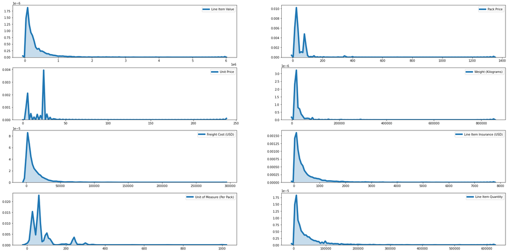

```python
# Checking Distribution of data in columns

fig,ax=plt.subplots(4,2,figsize=(30,15))

i,j=0,0
for col in num_index:
    sns.kdeplot(data[col],ax=ax[i,j],shade=True,linewidth=5,)
    j+=1
    if j==2:
        j=0
        i+=1
```

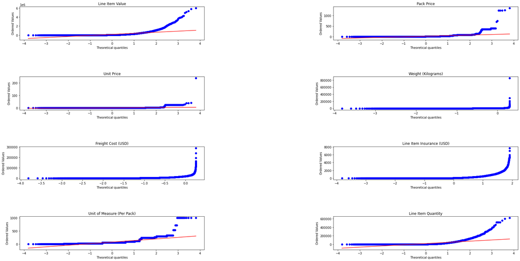

```python
# Checking Normality of distribution using Normal Probability Plot

from scipy import stats

fig,ax=plt.subplots(4,2,figsize=(30,15))
plt.subplots_adjust(
                    wspace=0.7,
                    hspace=1.1)

a,b=0,0
for col in num_index:
    stats.probplot(data[col],plot=ax[a,b])
    ax[a,b].set_title(col)
    b+=1
    if b==2:
        b=0
        a+=1

# It is observed that most of the features are Right skewed (might have outliers in the right tail)
```

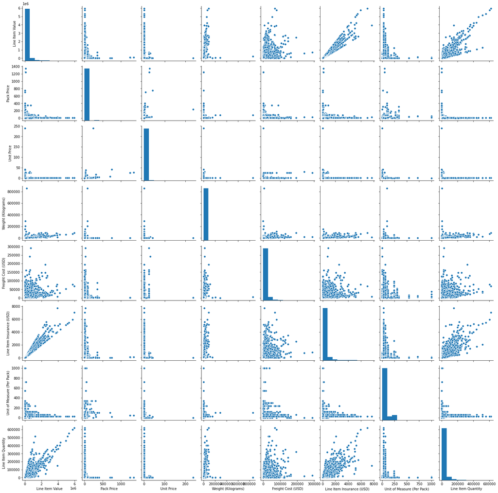

```python
# Visualizing Correlation b/w features ,using Scatter Plots

sns.pairplot(data[num_index])
```

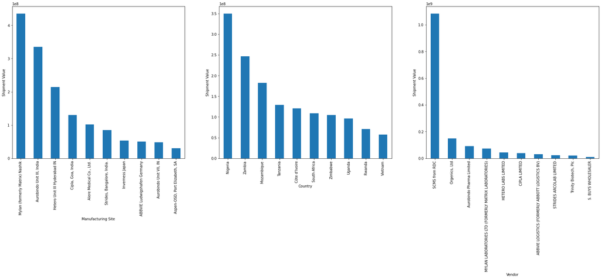

```python
fig,ax=plt.subplots(1,3,figsize=(30,8))

# Top 10 Manufacturing sites by Total Price/Value of Packs produced
data.groupby(['Manufacturing Site'])['Line Item Value'].sum().nlargest(10).plot(kind='bar',ax=ax[0])
ax[0].set_ylabel('Shipment Value')

# Top 10 Countries by Total Price/Value of Packs produced
data.groupby(['Country'])['Line Item Value'].sum().nlargest(10).plot(kind='bar',ax=ax[1])
ax[1].set_ylabel('Shipment Value')

# Top 10 Vendors sites by Total Price/Value of Packs produced
data.groupby(['Vendor'])['Line Item Value'].sum().nlargest(10).plot(kind='bar',ax=ax[2])
ax[2].set_ylabel('Shipment Value')
```

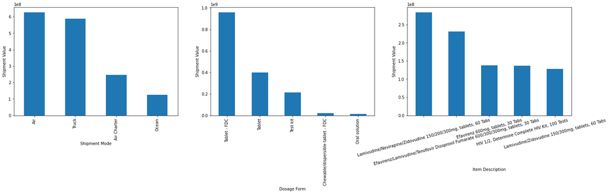

```python
fig,ax=plt.subplots(1,3,figsize=(25,5))
data.groupby(['Shipment Mode'])['Line Item Value'].sum().nlargest(5).plot(kind='bar',ax=ax[0])
ax[0].set_ylabel('Shipment Value')
data.groupby(['Dosage Form'])['Line Item Value'].sum().nlargest(5).plot(kind='bar',ax=ax[1])
ax[1].set_ylabel('Shipment Value')
data.groupby(['Item Description'])['Line Item Value'].sum().nlargest(5).plot(kind='bar',ax=ax[2])
plt.xticks(rotation=15)
ax[2].set_ylabel('Shipment Value')
```

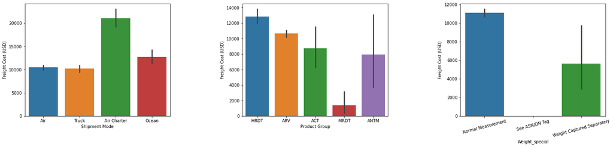

```python
fig,ax=plt.subplots(1,3,figsize=(25,5))
plt.subplots_adjust( wspace=0.5)

sns.barplot('Shipment Mode','Freight Cost (USD)',data=data,ax=ax[0])
sns.barplot('Product Group','Freight Cost (USD)',data=data,ax=ax[1])
sns.barplot('Weight_special','Freight Cost (USD)',data=data,ax=ax[2])
plt.xticks(rotation=15)
```

```python
# Checking for Null values
pd.DataFrame(data=data.isnull().sum().values,index=data.isnull().sum().index).T
```

|  | Country | Vendor | Manufacturing Site | Brand | Item Description | Product Group | Sub Classification | Molecule/Test Type | Dosage Form | Dosage | Managed By | Vendor INCO Term | Fulfill Via | Shipment Mode | Scheduled Delivery Date | Delivered to Client Date | Delivery Recorded Date | Unit of Measure (Per Pack) | Line Item Quantity | Line Item Value | Pack Price | Unit Price | First Line Designation | Weight (Kilograms) | Weight_special | Freight Cost (USD) | Freight_cost_special | Line Item Insurance (USD) |
| --- | --- | --- | --- | --- | --- | --- | --- | --- | --- | --- | --- | --- | --- | --- | --- | --- | --- | --- | --- | --- | --- | --- | --- | --- | --- | --- | --- | --- |
| 0 | 0 | 0 | 0 | 0 | 0 | 0 | 0 | 0 | 0 | 1736 | 0 | 0 | 0 | 360 | 0 | 0 | 0 | 0 | 0 | 0 | 0 | 0 | 0 | 3952 | 0 | 4126 | 0 | 287 |

```python
# Getting Columns with null values

null_val_cols=(data.isnull().sum()[data.isnull().sum()>0]).index
null_val_cols
```

```
Index(['Dosage', 'Shipment Mode', 'Weight (Kilograms)', 'Freight Cost (USD)',
       'Line Item Insurance (USD)'],
      dtype='object')
```

```python
# Random Sample Imputation for Categorical Columns

for col in ['Dosage', 'Shipment Mode']:
    rand_samples=data[col].dropna().sample(data[col].isnull().sum())
    rand_samples.index=data[data[col].isnull()].index
    data.loc[data[col].isnull(),col]=rand_samples

# KNN Imputation for numerical columns

from sklearn.impute import KNNImputer

for col in ['Weight (Kilograms)', 'Freight Cost (USD)','Line Item Insurance (USD)'] :
        imputer=KNNImputer(n_neighbors=10)
        data[col]=imputer.fit_transform(data[[col]])
```

```python
pd.DataFrame(data=data.isnull().sum().values,index=data.isnull().sum().index).T
```

|  | Country | Vendor | Manufacturing Site | Brand | Item Description | Product Group | Sub Classification | Molecule/Test Type | Dosage Form | Dosage | Managed By | Vendor INCO Term | Fulfill Via | Shipment Mode | Scheduled Delivery Date | Delivered to Client Date | Delivery Recorded Date | Unit of Measure (Per Pack) | Line Item Quantity | Line Item Value | Pack Price | Unit Price | First Line Designation | Weight (Kilograms) | Weight_special | Freight Cost (USD) | Freight_cost_special | Line Item Insurance (USD) |
| --- | --- | --- | --- | --- | --- | --- | --- | --- | --- | --- | --- | --- | --- | --- | --- | --- | --- | --- | --- | --- | --- | --- | --- | --- | --- | --- | --- | --- |
| 0 | 0 | 0 | 0 | 0 | 0 | 0 | 0 | 0 | 0 | 0 | 0 | 0 | 0 | 0 | 0 | 0 | 0 | 0 | 0 | 0 | 0 | 0 | 0 | 0 | 0 | 0 | 0 | 0 |

```python
data.shape
```

```
(10324, 28)
```

```python
# Encoding Categorical Columns

# frequency encode - 'Country', 'Vendor', 'Manufacturing Site', 'Brand', 'Item Description','Product Group', 'Sub Classification', 'Molecule/Test Type','Dosage Form',
#                       'Dosage', 'Managed By', 'Vendor INCO Term', 'Shipment Mode', 'Weight_special', 'Freight_cost_special'

# one hot encoding--'Fulfill Via','First Line Designation'
# ordinal encoding --- can be done in inco terms , shipment mode , -- domain knowledge is needed , moreover wedon't know personal preferences of the distributor , which might benefit him
```

```python
"""for cols in categ_index:
    print(f"\n {data[cols].value_counts().head(10)}")"""

# Observed that in all the categorical columns , there are a lare number of unique values
# We would not like to include all the unique values ; rather , we encode the top 10 categories and the remaining are classified as Other
```

```
'for cols in categ_index:\n    print(f"\n {data[cols].value_counts().head(10)}")'
```

```python
for col in categ_index:
    for i in range( data.shape[0]):
        if data[col].loc[i] in list(data[col].value_counts().head(10).to_dict().keys()):
            continue
        else :
            data[col].loc[i]="Other"
```

```python
for cols in categ_index:
    print(f"\n {data[cols].value_counts().head(10)}")
```

```
 Other            2512
South Africa     1406
Nigeria          1194
Côte d'Ivoire    1083
Uganda            779
Vietnam           688
Zambia            683
Haiti             655
Mozambique        631
Zimbabwe          538
Name: Country, dtype: int64

 SCMS from RDC                                            5404
Other                                                    1141
Orgenics, Ltd                                             754
S. BUYS WHOLESALER                                        715
Aurobindo Pharma Limited                                  668
Trinity Biotech, Plc                                      356
ABBVIE LOGISTICS (FORMERLY ABBOTT LOGISTICS BV)           347
PHARMACY DIRECT                                           326
MYLAN LABORATORIES LTD (FORMERLY MATRIX LABORATORIES)     317
HETERO LABS LIMITED                                       277
Name: Vendor, dtype: int64

 Aurobindo Unit III, India         3172
Other                             2052
Mylan (formerly Matrix) Nashik    1415
Hetero Unit III Hyderabad IN       869
Cipla, Goa, India                  665
Strides, Bangalore, India.         540
Alere Medical Co., Ltd.            481
Trinity Biotech, Plc               405
ABBVIE Ludwigshafen Germany        366
Inverness Japan                    345
Name: Manufacturing Site, dtype: int64

 Generic      7285
Other         978
Determine     799
Uni-Gold      373
```

[output cut: 96 more lines]

```

 Yes    7030
No     3294
Name: First Line Designation, dtype: int64

 Normal Measurement            6372
See ASN/DN Tag                2445
Weight Captured Separately    1507
Name: Weight_special, dtype: int64

 Normal Measurement                    6198
See ASN/DN Tag                        2445
Freight Included in Commodity Cost    1442
Invoiced Separately                    239
Name: Freight_cost_special, dtype: int64
```

```python
# While Frequency encoding , manually give less frequency for "Other" category as , there are a large no. of insignificant categories which aggregated to a large no.
# We do this so that the insignificant categories don't get unnecessarily higher weightage , while training

# columns to do manual encoding changes- Country , Vendor , Manufacturing site ,Brand , Item description , Molecule/Test type,Dosage

# frequency encode - ,'Product Group', 'Sub Classification','Dosage Form','Managed By', 'Vendor INCO Term', 'Shipment Mode', 'Weight_special', 'Freight_cost_special'

country_map=data.Country.value_counts().to_dict()
country_map["Other"]=min(country_map.values())-75
data.Country=data.Country.map((country_map))

vendor_map=data.Vendor.value_counts().to_dict()
vendor_map["Other"]=2
data.Vendor=data.Vendor.map(vendor_map)

manuf_site_map=data['Manufacturing Site'].value_counts().to_dict()
manuf_site_map["Other"]=2
data['Manufacturing Site']=data['Manufacturing Site'].map(manuf_site_map)

brand_map=data.Brand.value_counts().to_dict()
brand_map["Other"]=5
data.Brand=data.Brand.map(brand_map)

item_map=data['Item Description'].value_counts().to_dict()
item_map["Other"]=1
data['Item Description']=data['Item Description'].map(item_map)

test_type_map=data['Molecule/Test Type'].value_counts().to_dict()
test_type_map["Other"]=5
data['Molecule/Test Type']=data['Molecule/Test Type'].map(test_type_map)

dosage_map=data.Dosage.value_counts().to_dict()
dosage_map["Other"]=2
data.Dosage=data.Dosage.map(dosage_map)

prod_group_map=data['Product Group'].value_counts().to_dict()
data['Product Group']=data['Product Group'].map(prod_group_map)

sub_class_map=data['Sub Classification'].value_counts().to_dict()
data['Sub Classification']=data['Sub Classification'].map(sub_class_map)

dosage_form_map=data['Dosage Form'].value_counts().to_dict()
data['Dosage Form']=data['Dosage Form'].map(dosage_form_map)

managed_by_map=data['Managed By'].value_counts().to_dict()
data['Managed By']=data['Managed By'].map(managed_by_map)

inco_term_map=data['Vendor INCO Term'].value_counts().to_dict()
data['Vendor INCO Term']=data['Vendor INCO Term'].map(inco_term_map)

shipment_mode_map=data['Shipment Mode'].value_counts().to_dict()
data['Shipment Mode']=data['Shipment Mode'].map(shipment_mode_map)

wt_spcl_map=data['Weight_special'].value_counts().to_dict()
data['Weight_special']=data['Weight_special'].map(wt_spcl_map)

freight_spcl_map=data['Freight_cost_special'].value_counts().to_dict()
data['Freight_cost_special']=data['Freight_cost_special'].map(freight_spcl_map)

# one hot encoding--'Fulfill Via','First Line Designation'

data['Fulfill Via']=pd.get_dummies(data['Fulfill Via'],drop_first=True,dtype='float64') #---From RDC-1 ; Direct Drop-0

data['First Line Designation']=pd.get_dummies(data['First Line Designation'],drop_first=True,dtype='float64') #---Yes-1 ; No-0
```

```python
data
```

|  | Country | Vendor | Manufacturing Site | Brand | Item Description | Product Group | Sub Classification | Molecule/Test Type | Dosage Form | Dosage | Managed By | Vendor INCO Term | Fulfill Via | Shipment Mode | Scheduled Delivery Date | Delivered to Client Date | Delivery Recorded Date | Unit of Measure (Per Pack) | Line Item Quantity | Line Item Value | Pack Price | Unit Price | First Line Designation | Weight (Kilograms) | Weight_special | Freight Cost (USD) | Freight_cost_special | Line Item Insurance (USD) |
| --- | --- | --- | --- | --- | --- | --- | --- | --- | --- | --- | --- | --- | --- | --- | --- | --- | --- | --- | --- | --- | --- | --- | --- | --- | --- | --- | --- | --- |
| 0 | 1083 | 2 | 2 | 5 | 1 | 1728 | 1567 | 5 | 1575 | 1098 | 10265 | 2778 | 0.0 | 6324 | 2006-06-02 | 2006-06-02 | 2006-06-02 | 30 | 19 | 551.00 | 29.00 | 0.97 | 1.0 | 13.000000 | 6372 | 780.340000 | 6198 | 240.117626 |
| 1 | 688 | 668 | 3172 | 7285 | 1 | 8550 | 1955 | 877 | 214 | 664 | 10265 | 2778 | 0.0 | 6324 | 2006-11-14 | 2006-11-14 | 2006-11-14 | 240 | 1000 | 6200.00 | 6.20 | 0.03 | 1.0 | 358.000000 | 6372 | 4521.500000 | 6198 | 240.117626 |
| 2 | 1083 | 2 | 2 | 799 | 577 | 1728 | 1567 | 577 | 1575 | 708 | 10265 | 397 | 0.0 | 6324 | 2006-08-27 | 2006-08-27 | 2006-08-27 | 100 | 500 | 40000.00 | 80.00 | 0.80 | 1.0 | 171.000000 | 6372 | 1653.780000 | 6198 | 240.117626 |
| 3 | 688 | 2 | 2 | 7285 | 378 | 8550 | 6595 | 592 | 3532 | 523 | 10265 | 2778 | 0.0 | 6324 | 2006-09-01 | 2006-09-01 | 2006-09-01 | 60 | 31920 | 127360.80 | 3.99 | 0.07 | 1.0 | 1855.000000 | 6372 | 16007.060000 | 6198 | 240.117626 |
| 4 | 688 | 668 | 3172 | 7285 | 1 | 8550 | 6595 | 5 | 729 | 2 | 10265 | 2778 | 0.0 | 6324 | 2006-08-11 | 2006-08-11 | 2006-08-11 | 60 | 38000 | 121600.00 | 3.20 | 0.05 | 1.0 | 7590.000000 | 6372 | 45450.080000 | 6198 | 240.117626 |
| ... | ... | ... | ... | ... | ... | ... | ... | ... | ... | ... | ... | ... | ... | ... | ... | ... | ... | ... | ... | ... | ... | ... | ... | ... | ... | ... | ... | ... |
| 10319 | 538 | 5404 | 2 | 7285 | 1 | 8550 | 1955 | 707 | 239 | 2 | 10265 | 5404 | 1.0 | 2941 | 2015-07-31 | 2015-07-15 | 2015-07-20 | 60 | 166571 | 599655.60 | 3.60 | 0.06 | 0.0 | 3424.441306 | 2445 | 11103.234819 | 2445 | 705.790000 |
| 10320 | 1083 | 5404 | 869 | 7285 | 597 | 8550 | 6595 | 689 | 2749 | 732 | 10265 | 5404 | 1.0 | 2941 | 2015-07-31 | 2015-08-06 | 2015-08-07 | 60 | 21072 | 137389.44 | 6.52 | 0.11 | 0.0 | 3424.441306 | 2445 | 11103.234819 | 2445 | 161.710000 |
| 10321 | 683 | 5404 | 2 | 7285 | 1 | 8550 | 6595 | 5 | 2749 | 2 | 10265 | 5404 | 1.0 | 2941 | 2015-08-31 | 2015-08-25 | 2015-09-03 | 30 | 514526 | 5140114.74 | 9.99 | 0.33 | 0.0 | 3424.441306 | 1507 | 11103.234819 | 1442 | 5284.040000 |
| 10322 | 538 | 5404 | 1415 | 7285 | 597 | 8550 | 6595 | 689 | 2749 | 732 | 10265 | 5404 | 1.0 | 2941 | 2015-09-09 | 2015-08-04 | 2015-08-11 | 60 | 17465 | 113871.80 | 6.52 | 0.11 | 1.0 | 1392.000000 | 6372 | 11103.234819 | 1442 | 134.030000 |
| 10323 | 538 | 5404 | 665 | 7285 | 1 | 8550 | 1955 | 689 | 239 | 2 | 10265 | 5404 | 1.0 | 2941 | 2015-08-31 | 2015-08-04 | 2015-08-11 | 60 | 36639 | 72911.61 | 1.99 | 0.03 | 0.0 | 3424.441306 | 1507 | 11103.234819 | 1442 | 85.820000 |

10324 rows × 28 columns

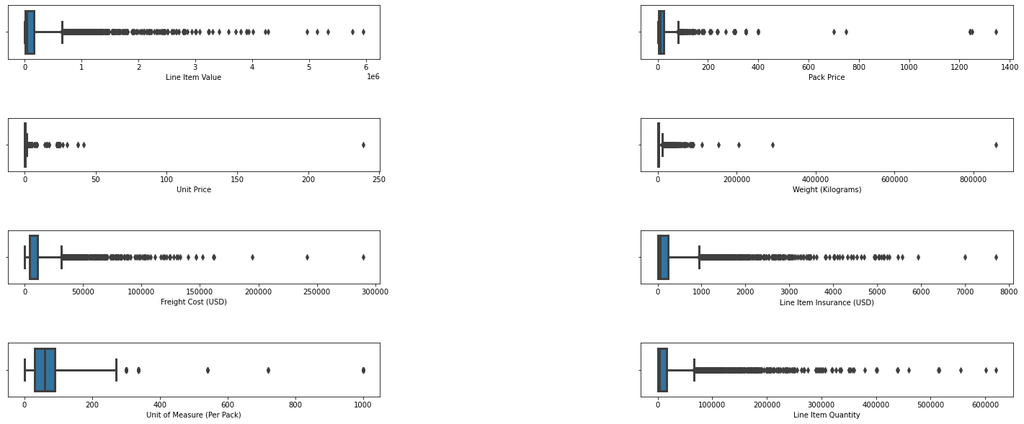

```python
# Outlier detection , feature selection/creation , model testing

fig,ax=plt.subplots(4,2,figsize=(25,10),squeeze=False)
plt.subplots_adjust(
                    wspace=0.7,
                    hspace=1.1)
i,j=0,0
for col in num_index:
    sns.boxplot(x=data[col],ax=ax[i,j],whis=3,linewidth=3,)

    j+=1
    if j==2:
        j=0
        i+=1

# we should think carefully about what is an outlier, why is it an outlier, and what should you do with the data if you choose to keep the outliers in the data.
# Note that "outliers" are rare. If they are not rare, they are either no outliers or your method/data collection is seriousely flawed

# It is important to figure out if a certain data value is a "true outlier" or a "influence or leverage point".
# Is it due to some measurement error or is it maybe due to excessive variability in the data?
```

```python
# 1e6 - 10^6

# Manually set outlier thresholds above which data is considered as outlier , based on sparsity and rarity

# Line Item Value - 2800000
# Pack Price - 200
# Unit Price - 30
# Weight - 100000
# Freight Cost - 120000
# Line Item Insurance - 3700
# Line Item Quantity - 270000
```

```python
num_index
```

```
Index(['Line Item Value', 'Pack Price', 'Unit Price', 'Weight (Kilograms)',
       'Freight Cost (USD)', 'Line Item Insurance (USD)',
       'Unit of Measure (Per Pack)', 'Line Item Quantity'],
      dtype='object')
```

```python
# Unit of Measure(per pack)--talthough we see outliers here , they might not be actually outliers. Since , Packs can be filled with pills , test kits or a combo of both ;
#                               since both occupy spaces varyingly , this leads too excessive variability in data.So ,we dont remove outliers here


# Freight Cost - This can excessively vary depending on the distance and route of shipment for the particular project.However ,we can't call them as outliers as they are
# not rare and contain important information .Hence , we don't completely impute the outliers
# We impute those points as outliers , after which the data points become very sparse ; so that our model doesn't overfit

# Similarly for all other columns , they definitely have some important information . Hence , we don't completely impute the outliers
# We manually impute those points as outliers , after which the data points become very sparse ; so that our model doesn't overfit



# Outlier Imputation for Line Item Value

b=0
for idx,j in enumerate(data['Line Item Value']):
    if j>2800000:
        b+=1
        data.loc[idx,'Line Item Value']=data['Line Item Value'].mean()
print("\n'Line Item Value'")
print(f"No. of outliers :{b}")

# Outlier Imputation for Pack Price

b=0
for idx,j in enumerate(data['Pack Price']):
    if j>200:
        b+=1
        data.loc[idx,'Pack Price']=data['Pack Price'].mean()
print("\n'Pack Price'")
print(f"No. of outliers :{b}")

# Outlier Imputation for  Unit Price

b=0
for idx,j in enumerate(data['Unit Price']):
    if j>30:
        b+=1
        data.loc[idx,'Unit Price']=data['Unit Price'].mean()
print("\n'Unit Price'")
print(f"No. of outliers :{b}")

# Outlier Imputation for Weight

b=0
for idx,j in enumerate(data['Weight (Kilograms)']):
    if j>100000:
        b+=1
        data.loc[idx,'Weight (Kilograms)']=data['Weight (Kilograms)'].mean()
print("\n'Weight (Kilograms)'")
print(f"No. of outliers :{b}")

# Outlier Imputation for Freight Cost

b=0
for idx,j in enumerate(data['Freight Cost (USD)']):
    if j>120000:
        b+=1
        data.loc[idx,'Freight Cost (USD)']=data['Freight Cost (USD)'].mean()
print("\n'Freight Cost (USD)'")
print(f"No. of outliers :{b}")

# Outlier Imputation for Line Item Insurance

b=0
for idx,j in enumerate(data['Line Item Insurance (USD)']):
    if j>3700:
        b+=1
        data.loc[idx,'Line Item Insurance (USD)']=data['Line Item Insurance (USD)'].mean()
print("\n'Line Item Insurance (USD)'")
print(f"No. of outliers :{b}")

# Outlier Imputation for Line Item Quantity
b=0
for idx,j in enumerate(data['Line Item Quantity']):
    if j>270000:
        b+=1
        data.loc[idx,'Line Item Quantity']=data['Line Item Quantity'].mean()
print("\n'Line Item Quantity'")
print(f"No. of outliers :{b}")
```

```
'Line Item Value'
No. of outliers :27

'Pack Price'
No. of outliers :71

'Unit Price'
No. of outliers :4

'Weight (Kilograms)'
No. of outliers :5

'Freight Cost (USD)'
No. of outliers :17

'Line Item Insurance (USD)'
No. of outliers :33

'Line Item Quantity'
No. of outliers :37
```

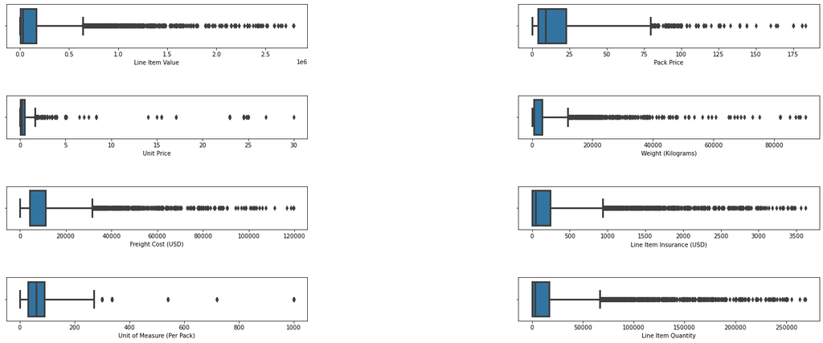

```python
fig,ax=plt.subplots(4,2,figsize=(25,10),squeeze=False)
plt.subplots_adjust(
                    wspace=0.7,
                    hspace=1.1)
i,j=0,0
for col in num_index:
    sns.boxplot(x=data[col],ax=ax[i,j],whis=3,linewidth=3,)

    j+=1
    if j==2:
        j=0
        i+=1
```

```python
# Feature Creation & Target Column Creation

# New Features - important KPI's in logistics )

# --------- Delay in Delivery
data["dlvry_delay"]=data['Delivered to Client Date']-data['Scheduled Delivery Date']
# +ve days denotes Late delivery

# --------- Delay in Delivery_verification_time
data["dlvry_verif_time_delay"]=data['Delivery Recorded Date']-data['Delivered to Client Date']

# time taken to place order , after Price Quote ws received by Client
#data['PQ First Sent to Client Date']-data['PO Sent to Vendor Date']

# value of goods = ( Line Item Value + Line Item insurance )/Line Item Quantity    -------- assigns higher value to sales driving shipments,rather than volume driving shipments
data["item_value"]=(data['Line Item Value']+data['Line Item Insurance (USD)'])/data['Line Item Quantity']

# Target column
data["Shipment_Price"]=data['Freight Cost (USD)']+data['Line Item Value']+data['Line Item Insurance (USD)']
```

```python
# Converting nanoseconds to days
data["dlvry_delay"]=pd.to_numeric(data.dlvry_delay)/(60*60*24*(10**9))
data["dlvry_verif_time_delay"]=pd.to_numeric(data.dlvry_verif_time_delay)/(60*60*24*(10**9))
```

```python
data.columns
```

```
Index(['Country', 'Vendor', 'Manufacturing Site', 'Brand', 'Item Description',
       'Product Group', 'Sub Classification', 'Molecule/Test Type',
       'Dosage Form', 'Dosage', 'Managed By', 'Vendor INCO Term',
       'Fulfill Via', 'Shipment Mode', 'Scheduled Delivery Date',
       'Delivered to Client Date', 'Delivery Recorded Date',
       'Unit of Measure (Per Pack)', 'Line Item Quantity', 'Line Item Value',
       'Pack Price', 'Unit Price', 'First Line Designation',
       'Weight (Kilograms)', 'Weight_special', 'Freight Cost (USD)',
       'Freight_cost_special', 'Line Item Insurance (USD)', 'dlvry_delay',
       'dlvry_verif_time_delay', 'item_value', 'Shipment_Price'],
      dtype='object')
```

```python
# Rearranging data and deleting date columns

data=data[['Country', 'Vendor', 'Manufacturing Site', 'Brand', 'Item Description',
       'Product Group', 'Sub Classification', 'Molecule/Test Type',
       'Dosage Form', 'Dosage', 'Managed By', 'Vendor INCO Term',
       'Fulfill Via', 'Shipment Mode', 'dlvry_delay','dlvry_verif_time_delay',
       'Unit of Measure (Per Pack)', 'Line Item Quantity', 'Line Item Value',
       'Pack Price', 'Unit Price', 'First Line Designation',
       'Weight (Kilograms)', 'Weight_special', 'Freight Cost (USD)',
       'Freight_cost_special', 'Line Item Insurance (USD)', 'item_value', 'Shipment_Price']]

data.head()
```

|  | Country | Vendor | Manufacturing Site | Brand | Item Description | Product Group | Sub Classification | Molecule/Test Type | Dosage Form | Dosage | Managed By | Vendor INCO Term | Fulfill Via | Shipment Mode | dlvry_delay | dlvry_verif_time_delay | Unit of Measure (Per Pack) | Line Item Quantity | Line Item Value | Pack Price | Unit Price | First Line Designation | Weight (Kilograms) | Weight_special | Freight Cost (USD) | Freight_cost_special | Line Item Insurance (USD) | item_value | Shipment_Price |
| --- | --- | --- | --- | --- | --- | --- | --- | --- | --- | --- | --- | --- | --- | --- | --- | --- | --- | --- | --- | --- | --- | --- | --- | --- | --- | --- | --- | --- | --- |
| 0 | 1083 | 2 | 2 | 5 | 1 | 1728 | 1567 | 5 | 1575 | 1098 | 10265 | 2778 | 0.0 | 6324 | 0.0 | 0.0 | 30 | 19.0 | 551.0 | 29.00 | 0.97 | 1.0 | 13.0 | 6372 | 780.34 | 6198 | 240.117626 | 41.637770 | 1571.457626 |
| 1 | 688 | 668 | 3172 | 7285 | 1 | 8550 | 1955 | 877 | 214 | 664 | 10265 | 2778 | 0.0 | 6324 | 0.0 | 0.0 | 240 | 1000.0 | 6200.0 | 6.20 | 0.03 | 1.0 | 358.0 | 6372 | 4521.50 | 6198 | 240.117626 | 6.440118 | 10961.617626 |
| 2 | 1083 | 2 | 2 | 799 | 577 | 1728 | 1567 | 577 | 1575 | 708 | 10265 | 397 | 0.0 | 6324 | 0.0 | 0.0 | 100 | 500.0 | 40000.0 | 80.00 | 0.80 | 1.0 | 171.0 | 6372 | 1653.78 | 6198 | 240.117626 | 80.480235 | 41893.897626 |
| 3 | 688 | 2 | 2 | 7285 | 378 | 8550 | 6595 | 592 | 3532 | 523 | 10265 | 2778 | 0.0 | 6324 | 0.0 | 0.0 | 60 | 31920.0 | 127360.8 | 3.99 | 0.07 | 1.0 | 1855.0 | 6372 | 16007.06 | 6198 | 240.117626 | 3.997522 | 143607.977626 |
| 4 | 688 | 668 | 3172 | 7285 | 1 | 8550 | 6595 | 5 | 729 | 2 | 10265 | 2778 | 0.0 | 6324 | 0.0 | 0.0 | 60 | 38000.0 | 121600.0 | 3.20 | 0.05 | 1.0 | 7590.0 | 6372 | 45450.08 | 6198 | 240.117626 | 3.206319 | 167290.197626 |

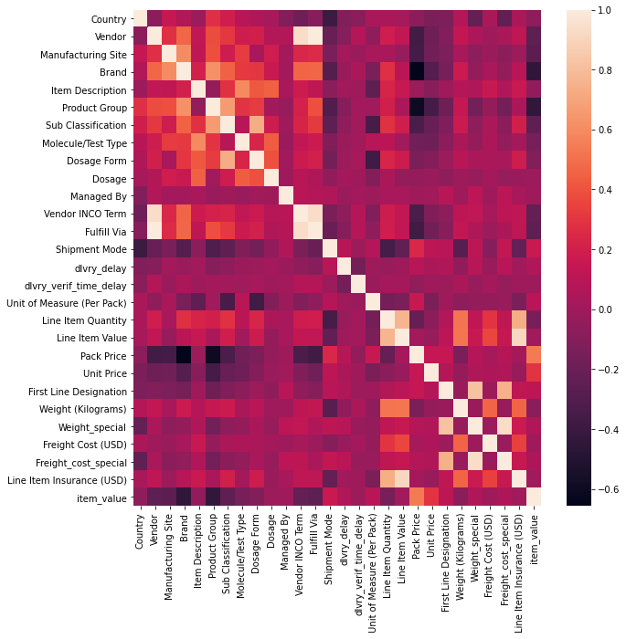

```python
# Feature Removal

plt.figure(figsize=(10,10))
sns.heatmap(data.drop(['Shipment_Price'],axis=1).corr())
```

```python
# Finding Higly Correlated Columns

def correlation(data,threshold):
    col_corr=set()
    cor=data.corr()
    for i in range(len(cor.columns)):
        for j in range(len(cor.columns)):
            if (abs(cor.iloc[i,j]) > threshold) and i!=j:
                if (cor.columns[j] in col_corr) or (cor.columns[i] in col_corr):
                    continue
                print("\n",cor.columns[i],"-----",cor.columns[j])
                print(abs(cor.iloc[i,j]))
                colname=cor.columns[i]
                col_corr.add(colname)
    return col_corr

a=correlation(data.drop(['Shipment_Price'],axis=1),0.9)
print('\n',a)
```

```
 Vendor ----- Vendor INCO Term
0.9367767103388067

 Vendor INCO Term ----- Fulfill Via
0.9367997828512018

 Line Item Value ----- Line Item Insurance (USD)
0.9120221547463065

 Weight_special ----- Freight_cost_special
0.9415039738045063

 {'Vendor INCO Term', 'Vendor', 'Line Item Value', 'Weight_special'}
```

```python
# Removing the highly correlated columns - {'Vendor INCO Term', 'Vendor', 'Line Item Value', 'Weight_special'}

data=data.drop(['Vendor INCO Term', 'Vendor', 'Line Item Value', 'Weight_special'],axis=1)
data.head()
```

|  | Country | Manufacturing Site | Brand | Item Description | Product Group | Sub Classification | Molecule/Test Type | Dosage Form | Dosage | Managed By | Fulfill Via | Shipment Mode | dlvry_delay | dlvry_verif_time_delay | Unit of Measure (Per Pack) | Line Item Quantity | Pack Price | Unit Price | First Line Designation | Weight (Kilograms) | Freight Cost (USD) | Freight_cost_special | Line Item Insurance (USD) | item_value | Shipment_Price |
| --- | --- | --- | --- | --- | --- | --- | --- | --- | --- | --- | --- | --- | --- | --- | --- | --- | --- | --- | --- | --- | --- | --- | --- | --- | --- |
| 0 | 1083 | 2 | 5 | 1 | 1728 | 1567 | 5 | 1575 | 1098 | 10265 | 0.0 | 6324 | 0.0 | 0.0 | 30 | 19.0 | 29.00 | 0.97 | 1.0 | 13.0 | 780.34 | 6198 | 240.117626 | 41.637770 | 1571.457626 |
| 1 | 688 | 3172 | 7285 | 1 | 8550 | 1955 | 877 | 214 | 664 | 10265 | 0.0 | 6324 | 0.0 | 0.0 | 240 | 1000.0 | 6.20 | 0.03 | 1.0 | 358.0 | 4521.50 | 6198 | 240.117626 | 6.440118 | 10961.617626 |
| 2 | 1083 | 2 | 799 | 577 | 1728 | 1567 | 577 | 1575 | 708 | 10265 | 0.0 | 6324 | 0.0 | 0.0 | 100 | 500.0 | 80.00 | 0.80 | 1.0 | 171.0 | 1653.78 | 6198 | 240.117626 | 80.480235 | 41893.897626 |
| 3 | 688 | 2 | 7285 | 378 | 8550 | 6595 | 592 | 3532 | 523 | 10265 | 0.0 | 6324 | 0.0 | 0.0 | 60 | 31920.0 | 3.99 | 0.07 | 1.0 | 1855.0 | 16007.06 | 6198 | 240.117626 | 3.997522 | 143607.977626 |
| 4 | 688 | 3172 | 7285 | 1 | 8550 | 6595 | 5 | 729 | 2 | 10265 | 0.0 | 6324 | 0.0 | 0.0 | 60 | 38000.0 | 3.20 | 0.05 | 1.0 | 7590.0 | 45450.08 | 6198 | 240.117626 | 3.206319 | 167290.197626 |

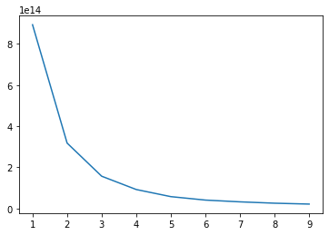

```python
# Clustering data to fit separate models on the different clusters , to check if  model generalises better after clustering , or as a whole
# Finding Optimal No. of Clusters

from sklearn.cluster import KMeans

inertia=[]
for i in range(1,10):
    kmeans=KMeans(n_clusters=i)
    kmeans.fit(data)
    inertia.append(kmeans.inertia_)

elbow=pd.DataFrame({'Cluster':range(1,10),'Inertia':inertia})
plt.plot(elbow.Cluster,elbow.Inertia)
```

```python
# From the elbow curve above , it seems reasonable to choose 3 clusters

kmeans=KMeans(n_clusters=3)
kmeans.fit(data)
data['Cluster']=kmeans.predict(data)
data.head()
```

|  | Country | Manufacturing Site | Brand | Item Description | Product Group | Sub Classification | Molecule/Test Type | Dosage Form | Dosage | Managed By | Fulfill Via | Shipment Mode | dlvry_delay | dlvry_verif_time_delay | Unit of Measure (Per Pack) | Line Item Quantity | Pack Price | Unit Price | First Line Designation | Weight (Kilograms) | Freight Cost (USD) | Freight_cost_special | Line Item Insurance (USD) | item_value | Shipment_Price | Cluster |
| --- | --- | --- | --- | --- | --- | --- | --- | --- | --- | --- | --- | --- | --- | --- | --- | --- | --- | --- | --- | --- | --- | --- | --- | --- | --- | --- |
| 0 | 1083 | 2 | 5 | 1 | 1728 | 1567 | 5 | 1575 | 1098 | 10265 | 0.0 | 6324 | 0.0 | 0.0 | 30 | 19.0 | 29.00 | 0.97 | 1.0 | 13.0 | 780.34 | 6198 | 240.117626 | 41.637770 | 1571.457626 | 1 |
| 1 | 688 | 3172 | 7285 | 1 | 8550 | 1955 | 877 | 214 | 664 | 10265 | 0.0 | 6324 | 0.0 | 0.0 | 240 | 1000.0 | 6.20 | 0.03 | 1.0 | 358.0 | 4521.50 | 6198 | 240.117626 | 6.440118 | 10961.617626 | 1 |
| 2 | 1083 | 2 | 799 | 577 | 1728 | 1567 | 577 | 1575 | 708 | 10265 | 0.0 | 6324 | 0.0 | 0.0 | 100 | 500.0 | 80.00 | 0.80 | 1.0 | 171.0 | 1653.78 | 6198 | 240.117626 | 80.480235 | 41893.897626 | 1 |
| 3 | 688 | 2 | 7285 | 378 | 8550 | 6595 | 592 | 3532 | 523 | 10265 | 0.0 | 6324 | 0.0 | 0.0 | 60 | 31920.0 | 3.99 | 0.07 | 1.0 | 1855.0 | 16007.06 | 6198 | 240.117626 | 3.997522 | 143607.977626 | 1 |
| 4 | 688 | 3172 | 7285 | 1 | 8550 | 6595 | 5 | 729 | 2 | 10265 | 0.0 | 6324 | 0.0 | 0.0 | 60 | 38000.0 | 3.20 | 0.05 | 1.0 | 7590.0 | 45450.08 | 6198 | 240.117626 | 3.206319 | 167290.197626 | 1 |

```python
data.Cluster.value_counts()
```

```
1    8791
0    1288
2     245
Name: Cluster, dtype: int64
```

```python
# Separating the 3 data clusters

data_c1=data[data.Cluster==0].drop(['Cluster'],axis=1).copy(deep=True)
data_c2=data[data.Cluster==1].drop(['Cluster'],axis=1).copy(deep=True)
data_c3=data[data.Cluster==2].drop(['Cluster'],axis=1).copy(deep=True)
```

```python
# Function to calculate ajusted r2 score

def adjusted_r2(r2,data):
    score=1-(1-r2)*(data.shape[0]-1)/(data.shape[0]-data.shape[1]-1)
    return score
```

```python
# Regression models to try
# Linear regression , lasso / regularised ,SVM regressor, KNN , rand forest regressor , XGB regressor
```

```python
#Trying LInear Regression

import numpy as np
from sklearn.model_selection import train_test_split
from sklearn.model_selection import cross_val_score , RepeatedStratifiedKFold
from sklearn.linear_model import LinearRegression

scores_linreg=[]

for i in [data,data_c1,data_c2,data_c3]:
            X=i.drop(['Shipment_Price'],axis=1)
            y=i['Shipment_Price']
            X_train,X_test,y_train,y_test=train_test_split(X,y,test_size=0.3,random_state=1)

            linreg=LinearRegression()
            linreg.fit(X_train,y_train)
            r2=linreg.score(X_test,y_test)
            adj_r2=adjusted_r2(r2=r2,data=i)
            scores_linreg.append((adj_r2))

print(f"Adj r2 score for Entire Data : {scores_linreg[0]}")
print(f"Adj r2 score for Data Cluster 1 : {scores_linreg[1]}")
print(f"Adj r2 score for Data Cluster 2 : {scores_linreg[2]}")
print(f"Adj r2 score for Data Cluster 3 : {scores_linreg[3]}")
```

```
Adj r2 score for Entire Data : 0.8014625033426527
Adj r2 score for Data Cluster 1 : 0.6727115882484896
Adj r2 score for Data Cluster 2 : 0.8152797920963445
Adj r2 score for Data Cluster 3 : 0.6310064482748541
```

```python
#Trying Out Elastic Net Regression

from sklearn.linear_model import ElasticNetCV ,ElasticNet
scores_elasticreg=[]
for i in [data,data_c1,data_c2,data_c3]:

            X=i.drop(['Shipment_Price'],axis=1)
            y=i['Shipment_Price']
            X_train,X_test,y_train,y_test=train_test_split(X,y,test_size=0.3,random_state=2)

            elasticCV=ElasticNetCV(alphas=None,cv=10)
            elasticCV.fit(X_train,y_train)
            elastic_net_reg=ElasticNet(alpha=elasticCV.alpha_,l1_ratio=0.5)
            elastic_net_reg.fit(X_train,y_train)
            r2=elastic_net_reg.score(X_test,y_test)
            adj_r2=adjusted_r2(r2=r2,data=i)
            scores_elasticreg.append((adj_r2))

print(f"r2 score for Entire Data : {scores_elasticreg[0]}")
print(f"r2 score for Data Cluster 1 : {scores_elasticreg[1]}")
print(f"r2 score for Data Cluster 2 : {scores_elasticreg[2]}")
print(f"r2 score for Data Cluster 3 : {scores_elasticreg[3]}")
```

```
r2 score for Entire Data : 0.6620559979120453
r2 score for Data Cluster 1 : 0.23333147581448643
r2 score for Data Cluster 2 : 0.48235291266186575
r2 score for Data Cluster 3 : 0.27089918804632207
```

```python
#Trying Out Elastic Net Regression

from sklearn.linear_model import RidgeCV ,Ridge
scores_ridgereg=[]
for i in [data,data_c1,data_c2,data_c3]:

            X=i.drop(['Shipment_Price'],axis=1)
            y=i['Shipment_Price']
            X_train,X_test,y_train,y_test=train_test_split(X,y,test_size=0.3,random_state=2)

            alphas=np.random.uniform(low=0,high=10,size=(50,))
            ridgeCV=RidgeCV(alphas=alphas,cv=10)
            ridgeCV.fit(X_train,y_train)
            ridge_reg=Ridge(alpha=ridgeCV.alpha_)
            ridge_reg.fit(X_train,y_train)
            r2=ridge_reg.score(X_test,y_test)
            adj_r2=adjusted_r2(r2=r2,data=i)
            scores_ridgereg.append((adj_r2))

print(f"r2 score for Entire Data : {scores_ridgereg[0]}")
print(f"r2 score for Data Cluster 1 : {scores_ridgereg[1]}")
print(f"r2 score for Data Cluster 2 : {scores_ridgereg[2]}")
print(f"r2 score for Data Cluster 3 : {scores_ridgereg[3]}")
```

```
r2 score for Entire Data : 0.906502473170007
r2 score for Data Cluster 1 : 0.6625554703968244
r2 score for Data Cluster 2 : 0.7983882215352294
r2 score for Data Cluster 3 : 0.647439833490822
```

```python
#Trying Out Support Vector Regression

from sklearn.svm import LinearSVR,SVR
from sklearn.preprocessing import StandardScaler
scaler_svm=StandardScaler()
scores_SVM_reg=[]
for i in [data,data_c1,data_c2,data_c3]:
            #scaler_svm.fit(i.drop(['Shipment_Price'],axis=1))
            #X=scaler_svm.transform(i.drop(['Shipment_Price'],axis=1))
            X=i.drop(['Shipment_Price'],axis=1)
            y=i['Shipment_Price']
            X_train,X_test,y_train,y_test=train_test_split(X,y,test_size=0.3,random_state=2)

            svm_reg=SVR(kernel="rbf")
            svm_reg.fit(X_train,y_train)
            r2=svm_reg.score(X_test,y_test)
            adj_r2=adjusted_r2(r2=r2,data=i)
            scores_SVM_reg.append((adj_r2))

print(f"r2 score for Entire Data : {scores_SVM_reg[0]}")
print(f"r2 score for Data Cluster 1 : {scores_SVM_reg[1]}")
print(f"r2 score for Data Cluster 2 : {scores_SVM_reg[2]}")
print(f"r2 score for Data Cluster 3 : {scores_SVM_reg[3]}")
```

```
r2 score for Entire Data : -0.18255493408086565
r2 score for Data Cluster 1 : -0.04523420128227129
r2 score for Data Cluster 2 : -0.23749163121148342
r2 score for Data Cluster 3 : -0.17498867583171096
```

```python
#Trying Decision Tree Regression
from sklearn.tree import DecisionTreeRegressor , plot_tree
from sklearn.metrics import r2_score

scores_dtree_reg=[]
for i in [data,data_c1,data_c2,data_c3]:
            X=i.drop(['Shipment_Price'],axis=1)
            y=i['Shipment_Price']
            X_train,X_test,y_train,y_test=train_test_split(X,y,test_size=0.3,random_state=2)
            dtree_reg=DecisionTreeRegressor()
            dtree_reg.fit(X_train,y_train)
            pred=dtree_reg.predict(X_test)
            r2=r2_score(y_test,pred)
            adj_r2=adjusted_r2(r2=r2,data=i)
            scores_dtree_reg.append((adj_r2))

print(f"r2 score for Entire Data  : {scores_dtree_reg[0]}")
print(f"r2 score for Data Cluster 1 : {scores_dtree_reg[1]}")
print(f"r2 score for Data Cluster 2 : {scores_dtree_reg[2]}")
print(f"r2 score for Data Cluster 3 : {scores_dtree_reg[3]}")
```

```
r2 score for Entire Data  : 0.9756605019085524
r2 score for Data Cluster 1 : 0.7726668858094312
r2 score for Data Cluster 2 : 0.9499326972716455
r2 score for Data Cluster 3 : 0.6209724312628135
```

```python
#Trying Random Forest Regressor
from sklearn.ensemble import RandomForestRegressor

scores_rand_forest=[]
for i in [data,data_c1,data_c2,data_c3]:
            X=i.drop(['Shipment_Price'],axis=1)
            y=i['Shipment_Price']
            X_train,X_test,y_train,y_test=train_test_split(X,y,test_size=0.3,random_state=2)
            rand_forest=RandomForestRegressor(min_samples_leaf=10,n_estimators=30)
            rand_forest.fit(X_train,y_train)
            pred=rand_forest.predict(X_test)
            r2=r2_score(y_test,pred)
            adj_r2=adjusted_r2(r2=r2,data=i)
            scores_rand_forest.append((adj_r2))

print(f"r2 score for Entire Data : {scores_rand_forest[0]}")
print(f"r2 score for Data Cluster 1 : {scores_rand_forest[1]}")
print(f"r2 score for Data Cluster 2 : {scores_rand_forest[2]}")
print(f"r2 score for Data Cluster 3 : {scores_rand_forest[3]}")
```

```
r2 score for Entire Data : 0.9674783918934399
r2 score for Data Cluster 1 : 0.846370105292314
r2 score for Data Cluster 2 : 0.9695294968973991
r2 score for Data Cluster 3 : 0.5897237971515654
```

```python
#Trying XGBoost Regressor

from xgboost import XGBRegressor

scores_xgb=[]
for i in [data,data_c1,data_c2,data_c3]:
            X=i.drop(['Shipment_Price'],axis=1)
            y=i['Shipment_Price']
            X_train,X_test,y_train,y_test=train_test_split(X,y,test_size=0.3,random_state=2)
            xgb_reg=XGBRegressor(subsample=0.7,max_depth=9,colsample_bytree=0.8,eta=0.1)
            xgb_reg.fit(X_train,y_train)
            pred=xgb_reg.predict(X_test)
            r2=r2_score(y_test,pred)
            adj_r2=adjusted_r2(r2=r2,data=i)
            scores_xgb.append((adj_r2))

print(f"r2 score for Entire Data : {scores_xgb[0]}")
print(f"r2 score for Data Cluster 1 : {scores_xgb[1]}")
print(f"r2 score for Data Cluster 2 : {scores_xgb[2]}")
print(f"r2 score for Data Cluster 3 : {scores_xgb[3]}")
```

```
r2 score for Entire Data : 0.9902594505950042
r2 score for Data Cluster 1 : 0.9499256667838698
r2 score for Data Cluster 2 : 0.988497404278208
r2 score for Data Cluster 3 : 0.8598913223396523
```

```python
#Trying KNN Regression

from sklearn.neighbors import KNeighborsRegressor
from sklearn.preprocessing import StandardScaler

scaler_knn=StandardScaler()
scores_KNN_reg=[]

for i in [data,data_c1,data_c2,data_c3]:
            scaler_knn.fit(i.drop(['Shipment_Price'],axis=1))
            X=scaler_knn.transform(i.drop(['Shipment_Price'],axis=1))
            y=i['Shipment_Price']
            X_train,X_test,y_train,y_test=train_test_split(X,y,test_size=0.3,random_state=2)
            knn=KNeighborsRegressor(n_neighbors=10)
            knn.fit(X_train,y_train)
            r2=knn.score(X_test,y_test)
            adj_r2=adjusted_r2(r2=r2,data=i)
            scores_KNN_reg.append((adj_r2))

print(f"r2 score for Entire Data : {scores_KNN_reg[0]}")
print(f"r2 score for Data Cluster 1 : {scores_KNN_reg[1]}")
print(f"r2 score for Data Cluster 2 : {scores_KNN_reg[2]}")
print(f"r2 score for Data Cluster 3 : {scores_KNN_reg[3]}")
```

```
r2 score for Entire Data : 0.904319729470703
r2 score for Data Cluster 1 : 0.5923392868709882
r2 score for Data Cluster 2 : 0.8542445272682004
r2 score for Data Cluster 3 : 0.24052581272137985
```

```python
scores=pd.DataFrame([scores_linreg,scores_elasticreg,scores_ridgereg,scores_SVM_reg,scores_dtree_reg,scores_rand_forest,scores_KNN_reg,scores_xgb]
             ,index=['Linreg-r2','Elastic-net r2','Ridge-r2','SVR-r2','Dtree-r2','Rand-Forest-r2','KNN-r2',"XGB-r2"],
             columns=['Entire Data','Cluster 1','Cluster 2','Cluster 3'])
scores
```

|  | Entire Data | Cluster 1 | Cluster 2 | Cluster 3 |
| --- | --- | --- | --- | --- |
| Linreg-r2 | 0.801463 | 0.672712 | 0.815280 | 0.631006 |
| Elastic-net r2 | 0.662056 | 0.233331 | 0.482353 | 0.270899 |
| Ridge-r2 | 0.906502 | 0.662555 | 0.798388 | 0.647440 |
| SVR-r2 | -0.182555 | -0.045234 | -0.237492 | -0.174989 |
| Dtree-r2 | 0.975661 | 0.772667 | 0.949933 | 0.620972 |
| Rand-Forest-r2 | 0.967478 | 0.846370 | 0.969529 | 0.589724 |
| KNN-r2 | 0.904320 | 0.592339 | 0.854245 | 0.240526 |
| XGB-r2 | 0.990259 | 0.949926 | 0.988497 | 0.859891 |

```python
for i in scores.columns:
    print(f"Best Model for {i} : {scores[i].idxmax()} ")

# From the above results, we can conclude that models generalise worse after clustering ,as compared to the whole dataset.
# Hence we don't need to to cluster the data
```

```
Best Model for Entire Data : XGB-r2
Best Model for Cluster 1 : XGB-r2
Best Model for Cluster 2 : XGB-r2
Best Model for Cluster 3 : XGB-r2
```

```python
# So, Best model is XGB Regression

X=data.drop(['Shipment_Price'],axis=1)
y=data['Shipment_Price']
X_train,X_test,y_train,y_test=train_test_split(X,y,test_size=0.3,random_state=2)

xgb_reg=XGBRegressor(subsample=0.7,max_depth=9,colsample_bytree=0.8,eta=0.1)
xgb_reg.fit(X_train,y_train)
```

```
XGBRegressor(base_score=0.5, booster='gbtree', colsample_bylevel=1,
             colsample_bynode=1, colsample_bytree=0.8, eta=0.1, gamma=0,
             gpu_id=-1, importance_type='gain', interaction_constraints='',
             learning_rate=0.100000001, max_delta_step=0, max_depth=9,
             min_child_weight=1, missing=nan, monotone_constraints='()',
             n_estimators=100, n_jobs=8, num_parallel_tree=1, random_state=0,
             reg_alpha=0, reg_lambda=1, scale_pos_weight=1, subsample=0.7,
             tree_method='exact', validate_parameters=1, verbosity=None)
```

```python
import pickle
filename="xgboost.pickle"
pickle.dump(xgb_reg,open(filename,'wb'))

model=pickle.load(open(filename,'rb'))
pred=model.predict(X_test)
r2_score(y_test,pred)
```

```
0.9902839836071644
```